# CM3070 Computer Science Final Project

### Results comparison

Using ensemble model and pooling the predictions of the best three models achieved a high accuracy of 99% and F1 score of 99% on the selected dataset.

| Model | Accuracy | Precision | Recall | F1 score |
| --- | --- | --- | --- | --- |
| Best convolutional network from scratch with data augmentation | 94.35 | 95.84 | 93.30 | 94.55 |
| EfficientNetB0 with fine tuning and data augmentation | 98.44 | 98.44 | 98.44 | 98.44 |
| Weight average prediction of the best three models | 99.05 | 99.05 | 99.24 | 99.03 |

### Examples of bird images

```python
#*********************************
# Source code
# Author: Collet
# Source: Deep Learning with Python. CHAPTER 5 Deep learning for computer vision [1]
#*********************************
def img_to_tensor(img_path, img_width, img_height):

    """Converts image located at img_path into a 4D image tensor

    Parameters
    ----------
    img_path : str
        file path of the image
    img_width : int
        width size of the image
    img_height : int
        height size of the image

    Returns
    -------
    img_tensor : numpy.ndarray
        4D image tensor
    """

    img = utils.load_img(img_path, target_size=(img_width, img_height))
    # convert image into tensor with normalized values between [0-1] instead of [0-255]
    img_tensor = utils.img_to_array(img)
    img_tensor = np.expand_dims(img_tensor, axis=0)
    img_tensor /= 255.

    return img_tensor
```

```python
bird1_img_path = os.path.join(TEST_DIR, 'CAPE MAY WARBLER', '1.jpg')
bird2_img_path = os.path.join(TEST_DIR, 'STRAWBERRY FINCH', '2.jpg')
bird1_img_tensor = img_to_tensor(bird1_img_path, REDUCED_IMG_SIZE, REDUCED_IMG_SIZE)
bird2_img_tensor = img_to_tensor(bird2_img_path, REDUCED_IMG_SIZE, REDUCED_IMG_SIZE)
```

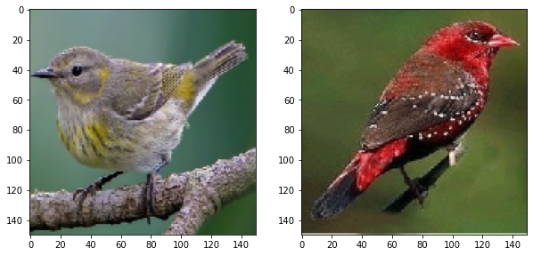

```python
# images of birds
fig, ax = plt.subplots(1,2, figsize=(10, 10))
ax[0].imshow(bird1_img_tensor[0])
ax[1].imshow(bird2_img_tensor[0])
plt.show()
```

### Prediction examples

```python
def ensemble_predict_print_bird(bird_class, weighted, w_efficient, w_scratch, w_inception):

    """Makes prediction based on the average of the predictions from the scratch, EfficientNet and Inception models

    Parameters
    ----------
    bird_class : string
        Actual bird class
    weighted : boolean
        True if using weighted average
    w_scratch : int
        weight for the scratch model
    w_efficient : int
        weight for the Efficientnet model
    w_inception : int
        weight for the Inception model

    Returns
    -------
    Prints image of bird, predicted class and actual class
    """

    img_path = os.path.join(TEST_DIR, bird_class, '1.jpg')
    img_tensor = img_to_tensor(img_path, IMG_SIZE, IMG_SIZE)
    img_scratch = img_tensor.copy()
    img_efficient = tf.keras.applications.efficientnet.preprocess_input(img_tensor)
    img_inception = tf.keras.applications.inception_v3.preprocess_input(img_tensor)

    # get a prediction from each model
    pred_a = model_efficient_aug.predict(img_efficient)
    pred_b = model_tuned_data_aug.predict(img_scratch)
    pred_c = model_inception_ft.predict(img_inception)

    # get prediction average or weighted average
    if(weighted):
        summed = (w_efficient * pred_a) + (w_scratch * pred_b) + (w_inception * pred_c)
    else:
        summed = np.sum([pred_a, pred_b, pred_c], axis=0)

    result = np.argmax(summed, axis=1)
    print(result)
    predicted_class = classes_dict[result[0]]

    plt.imshow(img_to_tensor(img_path, IMG_SIZE, IMG_SIZE)[0])
    print(f'Predicted class: {predicted_class}')
    print(f'Actual class: {bird_class}')
```

**Example 1: GREEN BROADBILL**

```
[198]
Predicted class: GREEN BROADBILL
Actual class: GREEN BROADBILL
```

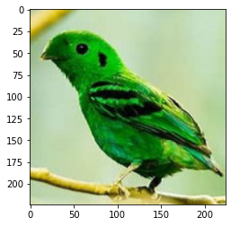

```python
ensemble_predict_print_bird('GREEN BROADBILL', True, efficient_weight, scratch_weight, inception_weight)
```

**Example 2: MYNA**

```
[268]
Predicted class: MYNA
Actual class: MYNA
```

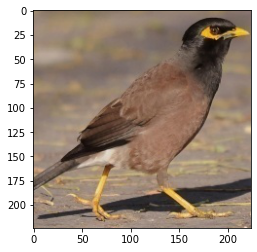

```python
ensemble_predict_print_bird('MYNA', True, efficient_weight, scratch_weight, inception_weight)
```

**Example 3: MALAGASY WHITE EYE**

```
[258]
Predicted class: MALAGASY WHITE EYE
Actual class: MALAGASY WHITE EYE
```

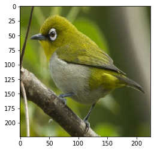

```python
ensemble_predict_print_bird('MALAGASY WHITE EYE', True, efficient_weight, scratch_weight, inception_weight)
```

## References

[1] CHOLLET, F. 2018. Deep Learning with Python. 1st ed. Manning Publications Co., New York.  
[2] PIOSENKA, G. 2022. Kaggle. BIRDS 400 - SPECIES IMAGE CLASSIFICATION. https://www.kaggle.com/datasets/gpiosenka/100-bird-species  
[3] WARD, J. AND BLACKWELL, T. 2021. University of London. CM3015 Machine Learning and Neural Networks. https://www.coursera.org/learn/uol-cm3015-machine-learning-and-neural-networks/home  
[4] KERAS. Keras API Reference: Probabilistic losses. https://keras.io/api/losses/probabilistic_losses/ https://keras.io/api/losses/probabilistic_losses/#categoricalcrossentropy-class  
[5] TENSORFLOW. Activations Softmax. https://www.tensorflow.org/api_docs/python/tf/keras/activations/softmax  
[6] KERAS. Keras API Reference: Optimizers RMSpop. https://keras.io/api/optimizers/rmsprop/  
[7] KERAS. Keras API Reference: Optimizers SGD. https://keras.io/api/optimizers/sgd/  
[8] KERAS. Keras API Reference: Optimizers Adam. https://keras.io/api/optimizers/adam/  
[9] O'MALLEY, T., BURSZTEIN, E. LONG, J. CHOLLET, F. 2019. Keras Tuner. https://github.com/keras-team/keras-tuner  
[10] ROSEBROCK, A. 2021. PY ImageSearch. Easy Hyperparameter Tuning with Keras Tuner and TensorFlow. https://pyimagesearch.com/2021/06/07/easy-hyperparameter-tuning-with-keras-tuner-and-tensorflow/  
[11] SIMONYAN, K. AND ZISSERMAN, A. 2015. Very Deep Convolutional Networks for Large-Scale Image Recognition. In 2015 ICLR 2015. San Diego, California. May 7-9 2015.  
[12] SZEGEDY, C., VANHOUCKE, V., IOFFE, S., SHLENS, J. AND WOJNA, Z. 2016. Rethinking the Inception Architecture for Computer Vision. In 2016 IEEE Conference on Computer Vision and Pattern Recognition (CVPR). Las Vegas, Nevada. 27-30 June 2016. pp. 2818-2826.  
[13] HE, K., ZHANG, X., REN, S. AND SUN, J. 2016. Deep Residual Learning for Image Recognition. In 2016 IEEE Conference on Computer Vision and Pattern Recognition (CVPR), Las Vegas, NV, USA, 2016 pp. 770-778.  
[14] TAN, M. AND LE, Q. 2022. 2019. EfficientNet: Improving Accuracy and Efficiency through AutoML and Model Scaling. https://ai.googleblog.com/2019/05/efficientnet-improving-accuracy-and.html  
[15] FU, Y. 2020. Keras. Image classification via fine-tuning with EfficientNet. https://keras.io/examples/vision/image_classification_efficientnet_fine_tuning/#transfer-learni ng-from-pretrained-weights